# Weather Events damage consequences in the US

RODCAR0

Sunday, May 24, 2015

## Synopsis

Based on the storm database published by NOAA (National Oceanic and Atmospheric Administration), the report shows which weather events have been most harmful with respect to population health and which ones with the greatest economic consequences.

The events in the database start in the year 1950 and end in November 2011 and it can be downloaded here. There is also a kind of codebook explaining the storm database, hit this [link](https://d396qusza40orc.cloudfront.net/repdata%2Fpeer2_doc%2Fpd01016005curr.pdf) to download it. As a brief summary, we can conclude the following:

1. The most harmful weather events causing the most fatalities and injuries to human beings across the US are the following: **a. Injuries**: *Tornado (91346), Wind (6957), Flood (6789)*, **b. Fatalities**: *Tornado (5633), Excessive heat (1903), Flash Flood (978)*
2. The greatest economic consequences have been due to the following weather events: **a. Property costs**: *Flood (144B), Hurricane/Thyphoon (69B), Tornado (56B)*, **b. Crop costs**: *Drought (13.9B USD), Flood (5.7B USD), River Flood (5B USD)*

For further details, check out the complete report here attached. In order to reproduce completely this analysis, you can find all kind of information and the R code in this [git repository](https://github.com/RODCAR0/RepData_PeerAssessment2).

## Data Processing

Let’s go step by step to see how the storm database has been processed with R in order to be analyzed properly.

These are the packages used to clean and plot (see point results) the data.

```r
suppressPackageStartupMessages(library(dplyr))

## English by default
Sys.setlocale("LC_ALL", "English")
```

We read the data that it’s compressed as bz2. Read csv is able to read these kind of files directly.

```r
stormData <- read.csv("./data/repdata_data_StormData.csv.bz2")
```

We should focus on human health damages and the greatest economic impact across the US, so we can dismiss those records without any consequences and filter out those fields unnecesaries for these purposes.

```r
damageData <- select(stormData, EVTYPE, FATALITIES, INJURIES, PROPDMG, PROPDMGEXP, CROPDMG, CROPDMGEXP) %>%
     filter((!is.na(FATALITIES) & FATALITIES > 0) | (!is.na(INJURIES) & INJURIES > 0) | (is.na(PROPDMG) | PROPDMG > 0)
            | (is.na(CROPDMG) | CROPDMG > 0))


damageData$PROPDMGEXP <- as.character(damageData$PROPDMGEXP)
damageData$CROPDMGEXP <- as.character(damageData$CROPDMGEXP)
```

As we can see in the R code, these are the fields used for the analysis:

1. *EVTYPE*. Weather event
2. *FATALITIES*. Number of deaths
3. *INJURIES*. People who were wounded
4. *PROPDMG*. Economic Property Damages
5. *PROPDMGEXP*. Exponential for PROPDMG
6. *CROPDMG*. Economic Crop Damages
7. *CROPDMGEXP*. Exponential for CROPDMG

We transform exponential fields from characters to numeric in order to calculate the economic values. These are the transformations to be applied:

1. *H/h* = 2 (Hundreds)
2. *K/k* = 3 (Thousands)
3. *M/m* = 6 (millions)
4. *B/b* = 9 (Billions)
5. *“-”* = 0 (Unknown)
6. *“+”* = 0 (Unknown)
7. *“”* = 0 (Unknown)
8. *“?”* = 0 (Unknown)

```r
## Convert Exponentials from letters to numbers.
damageData[(damageData$PROPDMGEXP == "H" | damageData$PROPDMGEXP == "h"), ]$PROPDMGEXP <- 2
damageData[(damageData$PROPDMGEXP == "K" | damageData$PROPDMGEXP == "k"), ]$PROPDMGEXP <- 3
damageData[(damageData$PROPDMGEXP == "M" | damageData$PROPDMGEXP == "m"), ]$PROPDMGEXP <- 6
damageData[(damageData$PROPDMGEXP == "B" | damageData$PROPDMGEXP == "b"), ]$PROPDMGEXP <- 9
damageData[damageData$PROPDMGEXP == "-", ]$PROPDMGEXP <- 0
damageData[damageData$PROPDMGEXP == "+", ]$PROPDMGEXP <- 0
damageData[damageData$PROPDMGEXP == "", ]$PROPDMGEXP <- 0
damageData[damageData$CROPDMGEXP == "?", ]$CROPDMGEXP <- 0

damageData[(damageData$CROPDMGEXP == "K" | damageData$CROPDMGEXP == "k"), ]$CROPDMGEXP <- 3
damageData[(damageData$CROPDMGEXP == "M" | damageData$CROPDMGEXP == "m"), ]$CROPDMGEXP <- 6
damageData[(damageData$CROPDMGEXP == "B" | damageData$CROPDMGEXP == "b"), ]$CROPDMGEXP <- 9
damageData[damageData$CROPDMGEXP == "", ]$CROPDMGEXP <- 0

damageData$PROPDMGEXP <- as.numeric(damageData$PROPDMGEXP)
damageData$CROPDMGEXP <- as.numeric(damageData$CROPDMGEXP)
```

For a more accurate analysis, a data processing should be performed for the field event types. In theory, there are 49 different types according to the code book provided by NOAA but we can see up to 488 after filtering out records without any consequences.

Now we are ready to calculate the economic values using the numeric exponentials. So two fields are added in the table:

1. *PROPDMGVAL* = Property Economic Cost (PROPDMG*10^PROPDMGEXP)
2. *CROPDMGVAL* = Crop Economic Cost (CROPDMG*10^CROPDMGEXP)

```r
damageData <- mutate(damageData, PROPDMGVAL = PROPDMG*10^PROPDMGEXP, CROPDMGVAL=CROPDMG*10^CROPDMGEXP)
```

## Results

At this point, using our tidy data (data frame **damageData**) we are ready to find out damages caused by weather events.

**FATALITIES/INJURIES**

We aggregate data by weather event types (EVTYPE). So two fields have been added to our table:

1. *TOTAL_FATALITIES* = Total fatalities aggregated by event type
2. *TOTAL_INJURIES* = Total injuries damage costs aggregated by event type

We are going to depict the first 20 more dangerous weather events.

```r
## Fatalities: Group by event types and summarise totals
humanDamageDataFat <- group_by(damageData, EVTYPE) %>% summarise(TOTAL_FATALITIES = sum(FATALITIES)) %>%
     arrange(desc(TOTAL_FATALITIES)) %>% head(20)

## Injuries: Group by event types and summarise totals
humanDamageDataInj <- group_by(damageData, EVTYPE) %>% summarise(TOTAL_INJURIES = sum(INJURIES)) %>%
     arrange(desc(TOTAL_INJURIES)) %>% head(20)
```

And here the R code chunk to create the plots (Fatalities and Injuries).

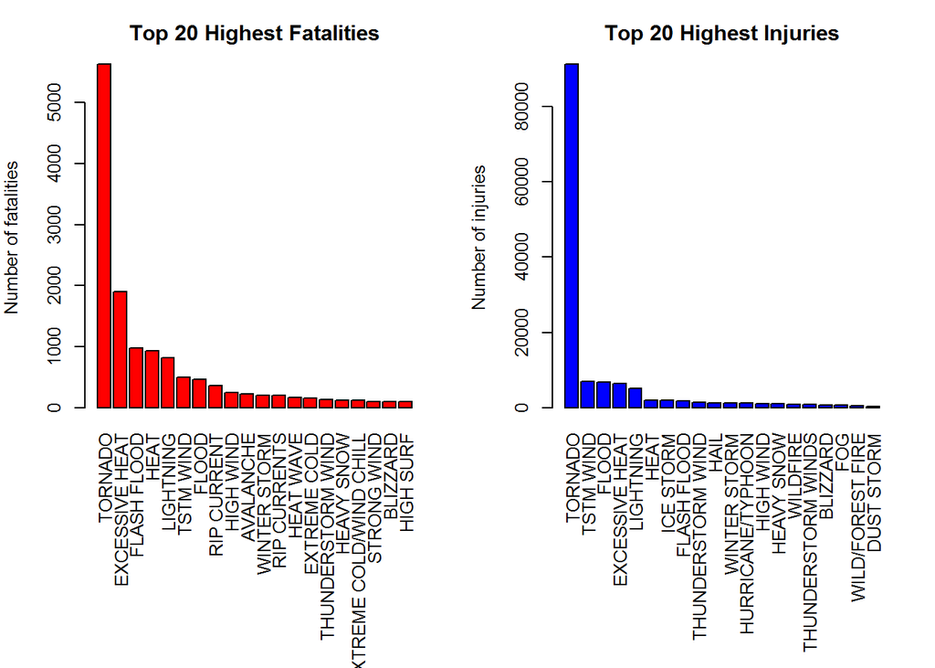

```r
#Layout for graphics
par(mfrow = c(1, 2), mar = c(12, 4, 3, 2), mgp = c(3, 1, 0), cex = 0.8)
#Barplot for Fatalities
barplot(humanDamageDataFat$TOTAL_FATALITIES, las = 3, names.arg = humanDamageDataFat$EVTYPE, main = "Top 20 Highest Fatalities",
        ylab = "Number of fatalities", col = "red")
#Barplot for Injuries
barplot(humanDamageDataInj$TOTAL_INJURIES, las = 3, names.arg = humanDamageDataInj$EVTYPE, main = "Top 20 Highest Injuries",
        ylab = "Number of injuries", col = "blue")
```

And here the table with the 20 most dangerous weather events

*Injuries*

```r
humanDamageDataInj
```

```
## Source: local data frame [20 x 2]
##
##                EVTYPE TOTAL_INJURIES
## 1             TORNADO          91346
## 2           TSTM WIND           6957
## 3               FLOOD           6789
## 4      EXCESSIVE HEAT           6525
## 5           LIGHTNING           5230
## 6                HEAT           2100
## 7           ICE STORM           1975
## 8         FLASH FLOOD           1777
## 9   THUNDERSTORM WIND           1488
## 10               HAIL           1361
## 11       WINTER STORM           1321
## 12  HURRICANE/TYPHOON           1275
## 13          HIGH WIND           1137
## 14         HEAVY SNOW           1021
## 15           WILDFIRE            911
## 16 THUNDERSTORM WINDS            908
## 17           BLIZZARD            805
## 18                FOG            734
## 19   WILD/FOREST FIRE            545
## 20         DUST STORM            440
```

*Fatalities*

```r
humanDamageDataFat
```

```
## Source: local data frame [20 x 2]
##
##                     EVTYPE TOTAL_FATALITIES
## 1                  TORNADO             5633
## 2           EXCESSIVE HEAT             1903
## 3              FLASH FLOOD              978
## 4                     HEAT              937
## 5                LIGHTNING              816
## 6                TSTM WIND              504
## 7                    FLOOD              470
## 8              RIP CURRENT              368
## 9                HIGH WIND              248
## 10               AVALANCHE              224
## 11            WINTER STORM              206
## 12            RIP CURRENTS              204
## 13               HEAT WAVE              172
## 14            EXTREME COLD              160
## 15       THUNDERSTORM WIND              133
## 16              HEAVY SNOW              127
## 17 EXTREME COLD/WIND CHILL              125
## 18             STRONG WIND              103
## 19                BLIZZARD              101
## 20               HIGH SURF              101
```

**ECONOMIC DAMAGE COSTS**

We aggregate data by weather event types (EVTYPE). So two fields have been added to our table:

1. *TOTAL_PROPDMGVAL* = Total Property damage costs aggregated by event type
2. *TOTAL_CROPDMGVAL* = Total Crop damage costs aggregated by event type

We are depicting the first 20 greater economic costs due to severe weather events.

```r
## Property costs: Group by event types and summarise totals
economicDamageDataProp <- group_by(damageData, EVTYPE) %>% summarise(TOTAL_PROPDMGVAL = sum(PROPDMGVAL)) %>%
     arrange(desc(TOTAL_PROPDMGVAL)) %>% head(20)
## Crop costs: Group by event types and summarise totals
economicDamageDataCrop <- group_by(damageData, EVTYPE) %>% summarise(TOTAL_CROPDMGVAL = sum(CROPDMGVAL)) %>%
     arrange(desc(TOTAL_CROPDMGVAL)) %>% head(20)
```

And here the R code chunk to create the plots (Property costs and Crop costs).

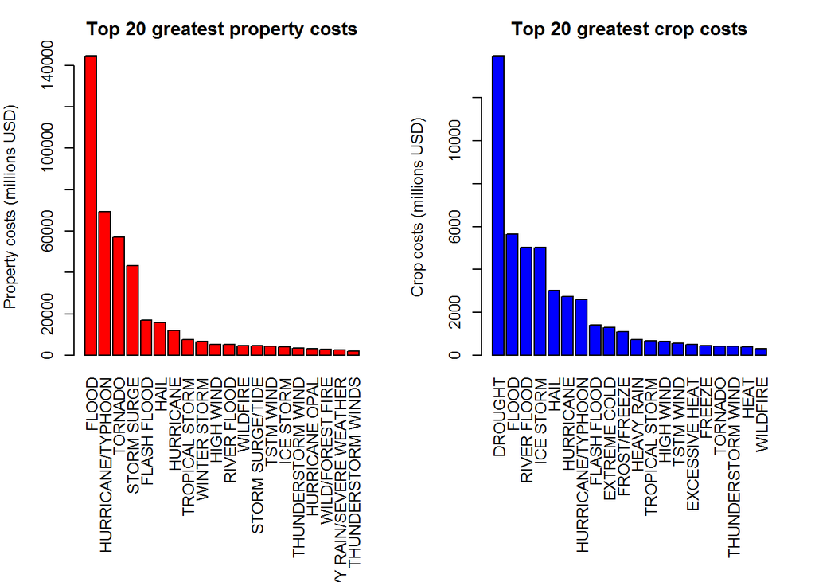

```r
#Layout for graphics
par(mfrow = c(1, 2), mar = c(12, 4, 3, 2), mgp = c(3, 1, 0), cex = 0.8)
#Barplot for Property damages
barplot(economicDamageDataProp$TOTAL_PROPDMGVAL/1000000, las = 3, names.arg = economicDamageDataProp$EVTYPE, main = "Top 20 greatest property costs",
        ylab = "Property costs (millions USD)", col = "red")
#Barplot for Crop damages
barplot(economicDamageDataCrop$TOTAL_CROPDMGVAL/1000000, las = 3, names.arg = economicDamageDataCrop$EVTYPE, main = "Top 20 greatest crop costs",
        ylab = "Crop costs (millions USD)", col = "blue")
```

And here the table with the 20 most dangerous weather events

*Property costs (USD)*

```r
economicDamageDataProp
```

```
## Source: local data frame [20 x 2]
##
##                       EVTYPE TOTAL_PROPDMGVAL
## 1                      FLOOD     144657709807
## 2          HURRICANE/TYPHOON      69305840000
## 3                    TORNADO      56947380677
## 4                STORM SURGE      43323536000
## 5                FLASH FLOOD      16822673979
## 6                       HAIL      15735267513
## 7                  HURRICANE      11868319010
## 8             TROPICAL STORM       7703890550
## 9               WINTER STORM       6688497251
## 10                 HIGH WIND       5270046295
## 11               RIVER FLOOD       5118945500
## 12                  WILDFIRE       4765114000
## 13          STORM SURGE/TIDE       4641188000
## 14                 TSTM WIND       4484928495
## 15                 ICE STORM       3944927860
## 16         THUNDERSTORM WIND       3483122472
## 17            HURRICANE OPAL       3172846000
## 18          WILD/FOREST FIRE       3001829500
## 19 HEAVY RAIN/SEVERE WEATHER       2500000000
## 20        THUNDERSTORM WINDS       1944590859
```

*Crop costs (USD)*

```r
economicDamageDataCrop
```

```
## Source: local data frame [20 x 2]
##
##               EVTYPE TOTAL_CROPDMGVAL
## 1            DROUGHT      13972566000
## 2              FLOOD       5661968450
## 3        RIVER FLOOD       5029459000
## 4          ICE STORM       5022113500
## 5               HAIL       3025954473
## 6          HURRICANE       2741910000
## 7  HURRICANE/TYPHOON       2607872800
## 8        FLASH FLOOD       1421317100
## 9       EXTREME COLD       1292973000
## 10      FROST/FREEZE       1094086000
## 11        HEAVY RAIN        733399800
## 12    TROPICAL STORM        678346000
## 13         HIGH WIND        638571300
## 14         TSTM WIND        554007350
## 15    EXCESSIVE HEAT        492402000
## 16            FREEZE        446225000
## 17           TORNADO        414953270
## 18 THUNDERSTORM WIND        414843050
## 19              HEAT        401461500
## 20          WILDFIRE        295472800
```